# Peak Tiling Initial Explorations

Let’s create a new column that indicates which position within the peak is being scrambled.

```r
data_all  <- data_all  %>%
    mutate(name = gsub('_flipped', '', name),
           name = gsub('_rc', '', name))
data_all <- data_all %>%
    mutate(category = case_when(grepl('random', .$name) ~ 'random',
                                grepl('neg', .$name) ~ 'negative',
                                TRUE ~ 'tile'))
data <- data_all %>% filter(category == 'tile')
data <- data %>%
    separate(name, into = c('peak_start', 'peak_end', 'strand', 'tile_loc'),
             sep = '_', remove = F, convert = T)
data <- data %>%
    mutate(tile_loc = gsub('pos', '', tile_loc)) %>%
    separate(tile_loc, into = c('tile_start', 'tile_end'),
             sep = '-', convert = T)
```

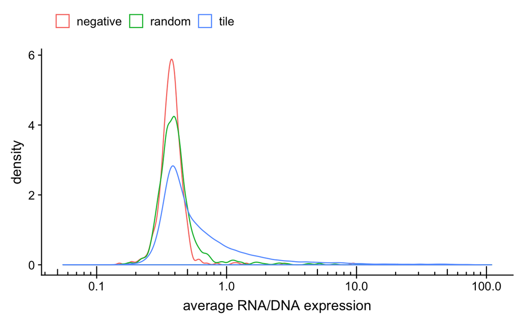

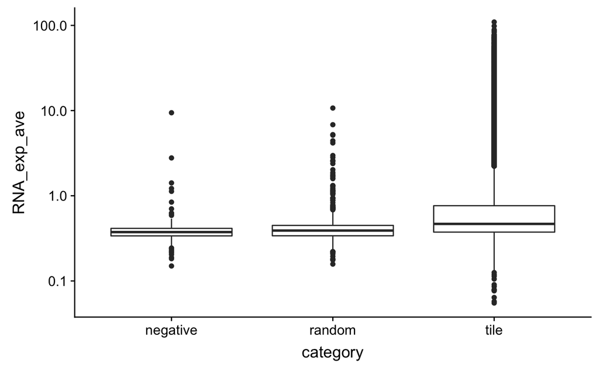

```r
negatives <- data_all %>% filter(category == 'negative')
neg_median <- median(negatives$RNA_exp_ave, na.rm = T)
```

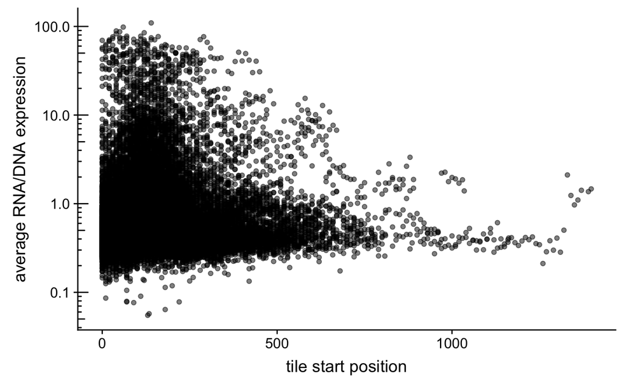

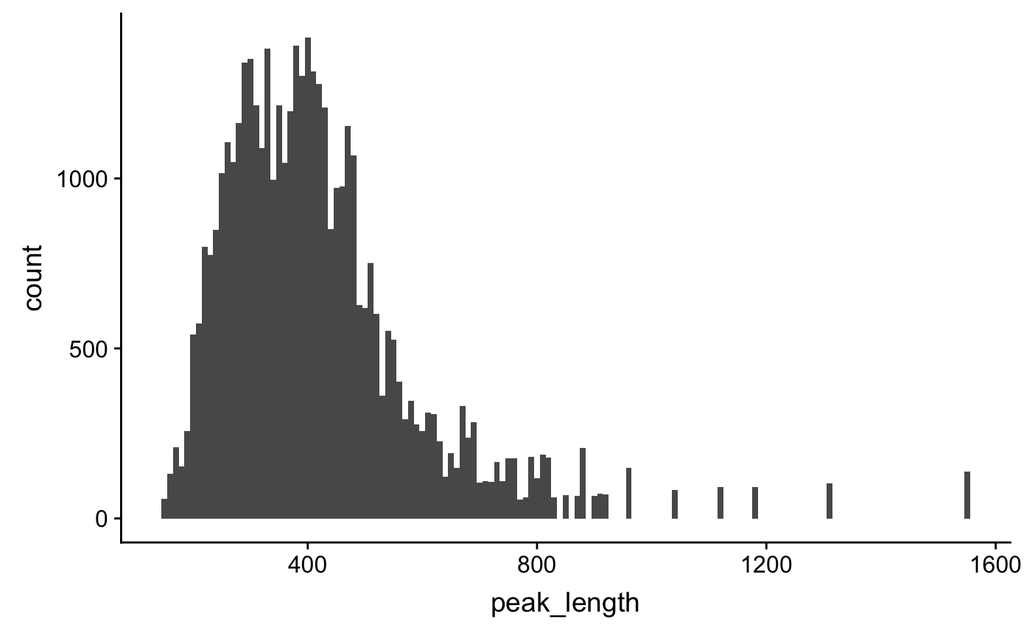

Let’s create a new tile start that is relative to the peak length

```r
data <- data %>%
    mutate(peak_length = peak_end - peak_start,
           tile_start_relative = tile_start / peak_length)
```

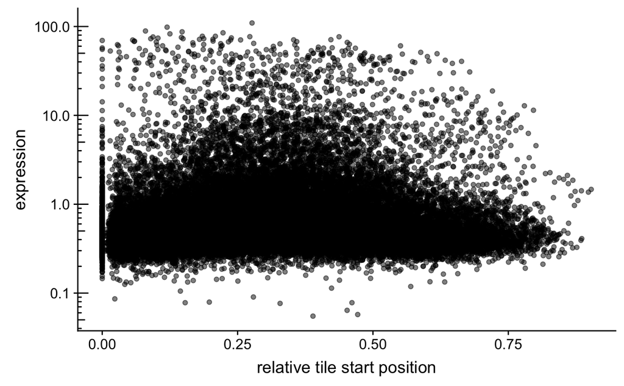

Let’s pick an example an just look at the individual tiles for a given peak.

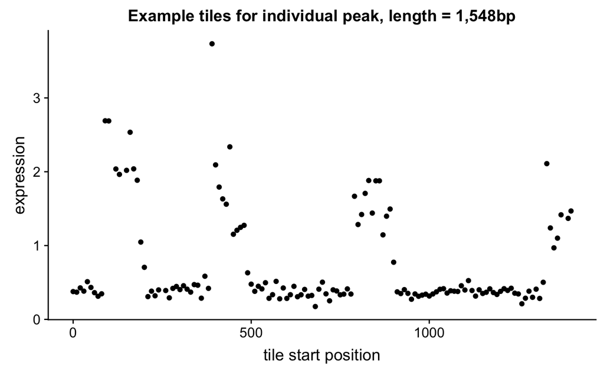

The peaks in expression look interesting, need a way to call enriched/significant points. Let’s try using 2-fold greater than median negative control.

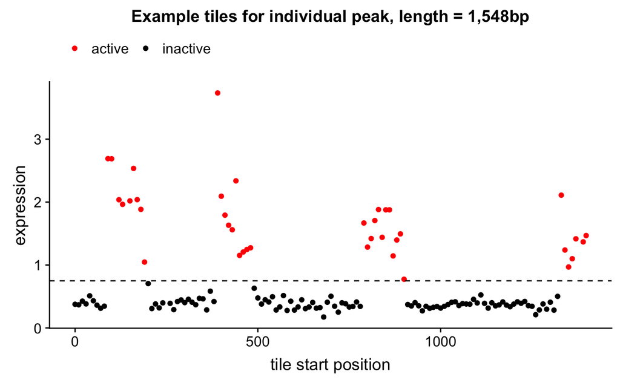

Seems to work pretty well here!

```r
data <- data %>%
    mutate(active = ifelse(RNA_exp_ave >= threshold, 'active', 'inactive'))
```

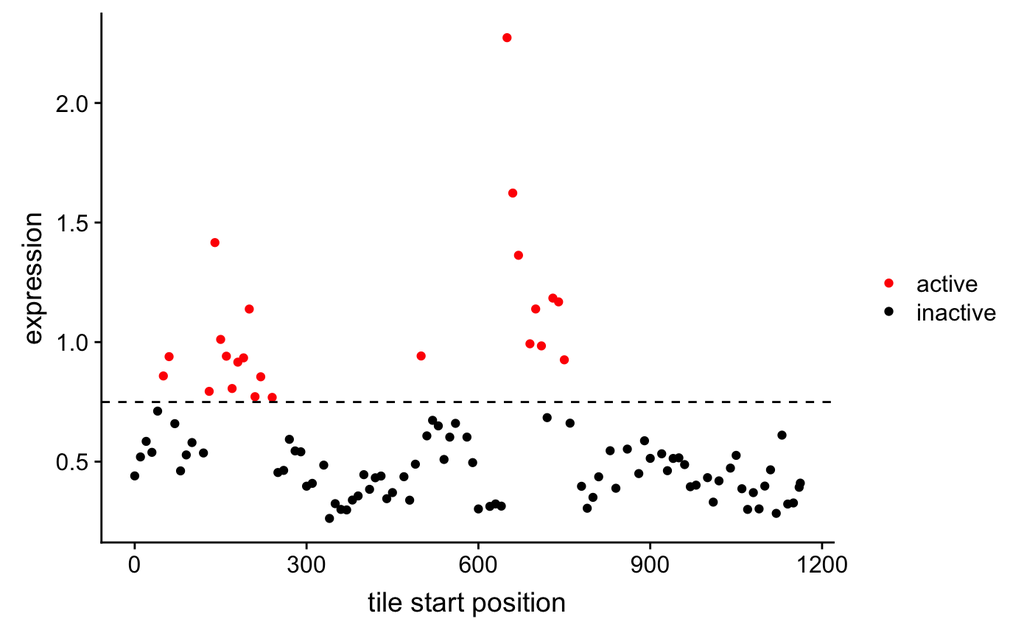

| category | active | n |
| --- | --- | --- |
| negative | active | 6 |
| negative | inactive | 460 |
| random | active | 41 |
| random | inactive | 892 |
| tile | active | 11096 |
| tile | inactive | 32126 |

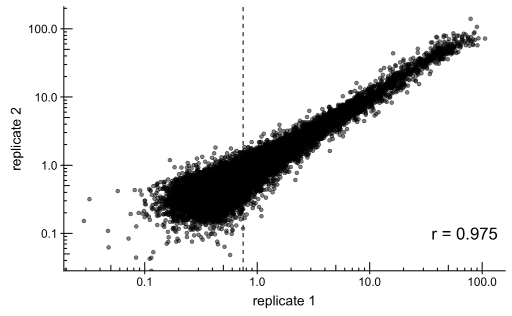

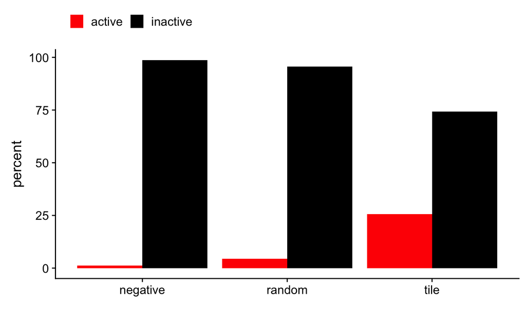

Can we predict if a tile is active? We could use gapped k-mer SVM.

```r
# get unique entries
data_unique <- data %>%
    group_by(name) %>%
    filter(n() == 1) %>%
    ungroup()

active <- filter(data_unique, active == 'active')
inactive <- filter(data_unique, active == 'inactive')
```

```r
# get unique entries
data_unique <- data %>%
    group_by(name) %>%
    filter(n() == 1) %>%
    ungroup()
active <- filter(data_unique, active == 'active')
inactive <- filter(data_unique, active == 'inactive')
# split active into train and test
train_size = 0.75
train_index <- base::sample(seq(1:nrow(active)),
                            size = nrow(active) * train_size,
                            replace = F)
write.fasta(as.list(active$variant[train_index]),
            names = active$name[train_index], nbchar = 150,
            file.out = '../../processed_data/peak_tile/gkmsvm_active_train.fasta')
write.fasta(as.list(active$variant[-train_index]),
            names = active$name[!train_index], nbchar = 150,
            file.out = '../../processed_data/peak_tile/gkmsvm_active_test.fasta')
write.fasta(as.list(active$variant),
            names = active$name,
            nbchar = 150,
            file.out = '../../processed_data/peak_tile/peak_tile_active.fasta')
# split negative into train and test
inactive_train_size = 0.75
inactive_train_index <- base::sample(seq(1:nrow(inactive)),
                            size = nrow(inactive) * inactive_train_size,
                            replace = F)
write.fasta(as.list(inactive$variant[inactive_train_index]),
            names = inactive$name[inactive_train_index], nbchar = 150,
            file.out = '../../processed_data/peak_tile/gkmsvm_inactive_train.fasta')
write.fasta(as.list(inactive$variant[-inactive_train_index]),
            names = inactive$name[!inactive_train_index], nbchar = 150,
            file.out = '../../processed_data/peak_tile/gkmsvm_inactive_test.fasta')
write.fasta(as.list(inactive$variant),
            names = inactive$name,
            nbchar = 150,
            file.out = '../../processed_data/peak_tile/peak_tile_inactive.fasta')
# this takes an entire day to run, so let's not do this
# gkmsvm_kernel(posfile = "../../processed_data/peak_tile/gkmsvm_active_train.fasta",
#               negfile = "../../processed_data/peak_tile/gkmsvm_inactive_train.fasta",
#               outfile = '../../processed_data/peak_tile/gkmsvm_kernel_10mer_8ungapped.out',
#               L = 10, K = 8)
```

```r
# # perform SVM training with cross-validation
# gkmsvm_trainCV(kernelfn = '../../processed_data/peak_tile/gkmsvm_kernel_10mer_8ungapped.out',
#                posfn= "../../processed_data/peak_tile/gkmsvm_active_train.fasta",
#                negfn = "../../processed_data/peak_tile/gkmsvm_inactive_train.fasta",
#                svmfnprfx='../../processed_data/peak_tile/tile_svm_10mer_8ungapped',
#                outputCVpredfn='../../processed_data/peak_tile/tile_svm_10mer_8ungapped_cvpred',
#                outputROCfn='../../processed_data/peak_tile/tile_svm_10mer_8ungapped_roc',
#                L = 10, K = 8)
```

gkmSVM was taking way too long, so decided to use neural network to classify active and inactive peaks. I ran the hyperparameter tuning for 100 trials, 4 layers, minimum of 5 and maximum of 100 layers.

Results:

```
Best hyperparameters: {'dropout': 0.43898735908905606, 'pool_width': 9, 'conv_width': array([14, 11,  5, 13]), 'num_filters': array([85, 81, 49, 52])}
Test results: Loss: 0.4146      Balanced Accuracy: 66.88%        auROC: 0.913    auPRC: 0.830
        Recall at 5%|10%|20% FDR: 32.8%|52.4%|70.1%      Num Positives: 2171     Num Negatives: 6154
```

I re-trained the model with the exact same parameters and got these results:

```
Finished training after 49 epochs.
Test results: Loss: 0.5336      Balanced Accuracy: 83.02%        auROC: 0.904    auPRC: 0.808
        Recall at 5%|10%|20% FDR: 23.5%|39.8%|64.1%      Num Positives: 2171     Num Negatives: 6154
```

Let’s look at the curves.

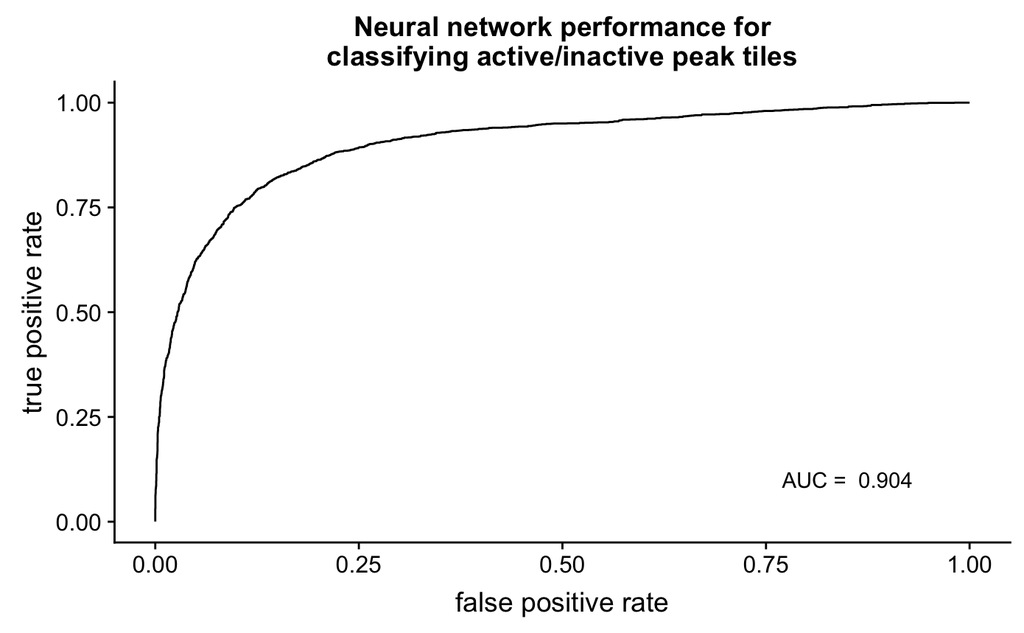

```r
roc_info <- read.table('../../processed_data/peak_tile/hyperparam_tuned_best_retrain_roc_info.txt',
                       sep = ',', col.names = c('fpr', 'tpr', 'threshold'))
auc <- pracma::trapz(roc_info$fpr, roc_info$tpr)
ggplot(roc_info, aes(fpr, tpr)) + geom_line() +
    labs(x = 'false positive rate', y = 'true positive rate',
         title = 'Neural network performance for\nclassifying active/inactive peak tiles') +
    annotate('text', x = 0.85, y = 0.10, label = paste('AUC = ', signif(auc, 3)))
```

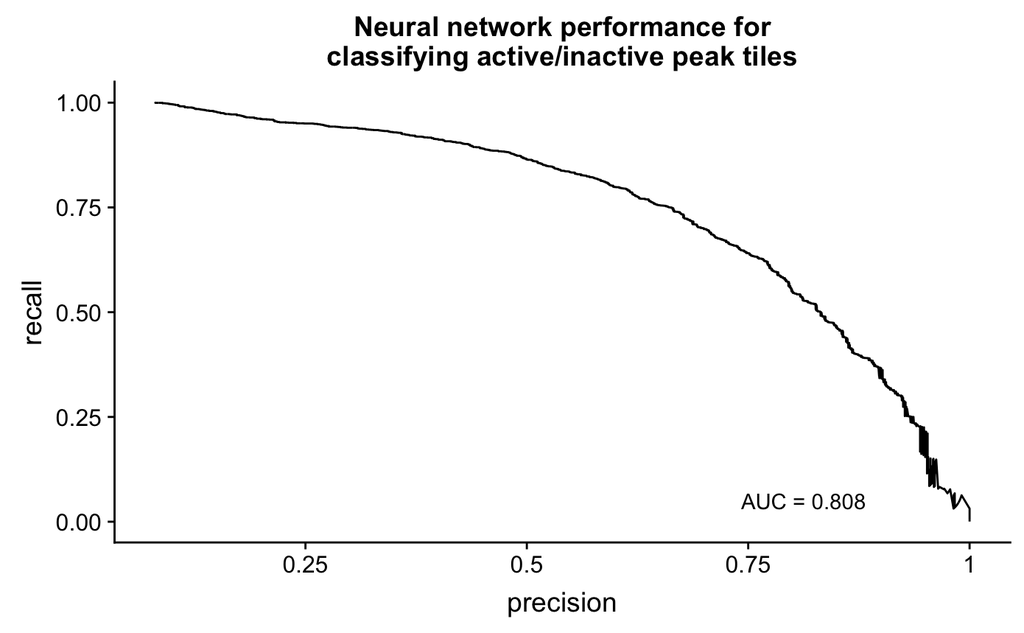

```r
pr_info <- read.table('../../processed_data/peak_tile/hyperparam_tuned_best_retrain_pr_info.txt',
                      sep = ',', col.names = c('precision', 'recall', 'threshold'))
auprc <- pracma::trapz(pr_info$precision, pr_info$recall)
ggplot(pr_info, aes(precision, recall)) + geom_line() +
    scale_x_continuous(labels = seq(0, 1, 0.25)) +
    annotate('text', x = 0.85, y = 0.05, label = 'AUC = 0.808') +
    labs(title = 'Neural network performance for\nclassifying active/inactive peak tiles')
```

Let’s output the quantitative data and try training neural network for regression.

```r
write.table(select(data_unique, variant, RNA_exp_ave), file = '../../processed_data/peak_tile/peak_tile_expression_only.txt',
            sep = '\t', col.names = F, row.names = F, quote = F)
```

Results:

```
Best hyperparameters: {'dropout': 0.17902804957413876, 'pool_width': 8, 'conv_width': array([19, 17,  3,  3]), 'num_filters': array([50, 76, 19, 79])}
Test results: 0.89571563407
```

```r
reg_predictions <- read.table('../../processed_data/peak_tile/hyperparam_tuned_regression_peak_tile_predictions.txt', sep = '\t', col.names = c('sequence', 'predicted', 'observed'))
corr <- cor(reg_predictions$observed, reg_predictions$predicted)
corr_log <- cor(log(reg_predictions$observed), log(reg_predictions$predicted), use = 'p')
```

```
NaNs produced
```

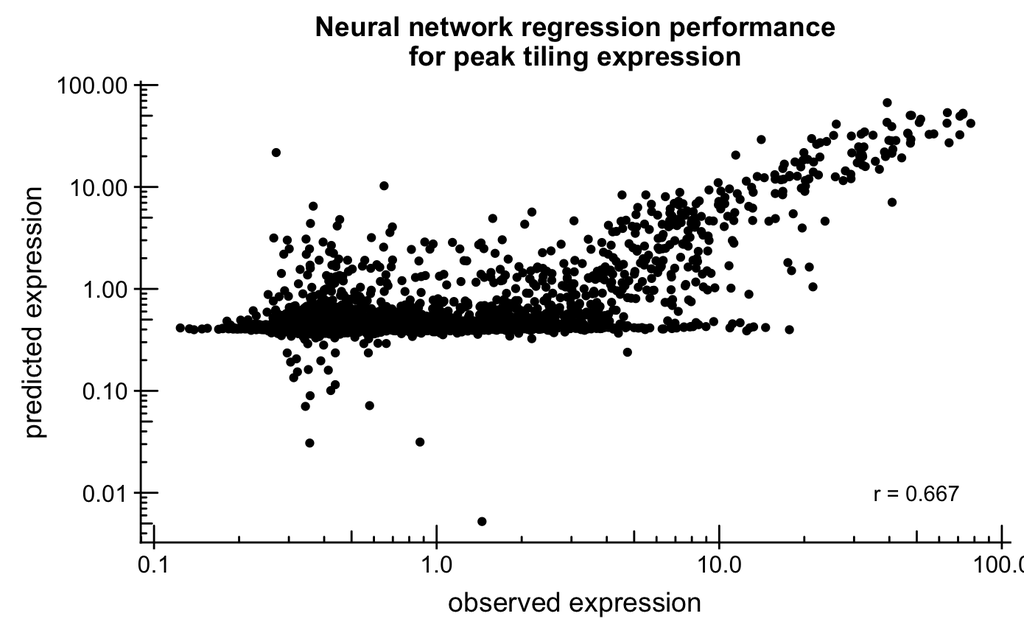

```r
ggplot(reg_predictions, aes(observed, predicted)) + geom_point() +
    scale_x_log10(breaks = c(0, 0.01, 0.1, 1, 10, 100)) + scale_y_log10(breaks = c(0, 0.01, 0.1, 1, 10, 100)) +
    # scale_x_log10(limits = c(0.01, 100)) + scale_y_log10(limits = c(0.01, 100)) +
    annotation_logticks(sides = 'bl') +
    annotate('text', x = 50, y = 0.01, label = paste0('r = ', signif(corr_log, 3))) +
    labs(x = 'observed expression', y = 'predicted expression',
         title = 'Neural network regression performance\nfor peak tiling expression')
```

Let’s see which motifs are enriched between active and inactive tiles.

Write PWMs to file

```r
MASS:write.matrix(just_pwms, 'test.txt')
```

[output not shown]

```r
options(scipen = 0)
report <- groupReport(enrich_result)
report
```

```
An object of class 'MotifEnrichmentReport':
    rank     target         id         raw.score              p.value
1      1  IDrL_9-36  IDrL_9-36  4.38428160358384                    0
2      2 OmpR_17-11 OmpR_17-11  12.5673573340305 9.79766425957515e-70
3      3  IDrL_9-39  IDrL_9-39  1.65753926803025  1.9400821962686e-66
4      4   IDnR_6-5   IDnR_6-5 0.984832472039797 3.31123677465449e-63
5      5   IDc_16-4   IDc_16-4  6.72499067134654 1.76147152430695e-58
6      6   IDrP_8-3   IDrP_8-3 0.891146744319094 7.93725763357821e-52
7      7  FNR_17-53  FNR_17-53  5.93696563032489 5.33588383475799e-37
8      8  ArgP_14-0  ArgP_14-0  2.53500374494908 4.55883970762233e-35
9      9   IDrL_9-3   IDrL_9-3  1.12323377034597 5.08090817103723e-34
10    10  MetJ_10-6  MetJ_10-6  1.08224602643601 6.07675812530593e-34
...  ...        ...        ...               ...                  ...
97    97  FhlA_30-0  FhlA_30-0  1.38886616555904    0.999999998132652
        top.motif.prop
1       0.168069611274
2    0.138844225858318
3    0.100728270122009
4   0.0838929348340112
5    0.107348907594817
6   0.0769885557552256
7   0.0819067435921687
8   0.0680979854345976
9   0.0760427504019673
10  0.0625177338503736
...                ...
97                   0
```

```r
signif <- report[p.adjust(report$p.value, 'fdr') <= 0.05]
print(length(report$pwms))
```

```
[1] 97
```

```r
print(length(signif$pwms))
```

```
[1] 86
```

Let’s look at the inactive tiles.

```r
inactive_report <- groupReport(inactive_enrich_result)
inactive_report
```

```
An object of class 'MotifEnrichmentReport':
    rank     target         id         raw.score               p.value
1      1  IDrL_9-36  IDrL_9-36  3.07081578229842                     0
2      2 OmpR_17-11 OmpR_17-11  8.09198068229515 2.72631223481143e-110
3      3   IDc_16-4   IDc_16-4   4.5563507328388   1.3205171283039e-79
4      4  IDrL_9-39  IDrL_9-39  1.20549903155687  7.86385816363878e-72
5      5   IDrL_9-3   IDrL_9-3  1.08346785342343  2.97569233993353e-70
6      6   IDrP_8-3   IDrP_8-3 0.829335027038936  7.60623717507542e-62
7      7  ArgP_14-0  ArgP_14-0  2.14285635616472  3.27275259887611e-55
8      8  FNR_17-53  FNR_17-53  3.97510500385804  1.51102820188136e-49
9      9  CpxR_14-8  CpxR_14-8  5.29363573780546  1.22168900447334e-38
10    10  TorR_10-5  TorR_10-5  1.41877979930676  1.28035781137779e-32
...  ...        ...        ...               ...                   ...
97    97  FhlA_30-0  FhlA_30-0 0.938636349581666                     1
          top.motif.prop
1      0.131203503912917
2      0.106631026375962
3     0.0898843837557567
4     0.0992560626066793
5     0.0954236578532092
6     0.0884029499855077
7     0.0864706450677917
8     0.0837332131010273
9     0.0827026504782455
10    0.0837976232649512
...                  ...
97  9.66152458858008e-05
```

```r
inactive_signif <- inactive_report[p.adjust(inactive_report$p.value, 'fdr') <= 0.05]
print(length(inactive_signif$pwms))
```

```
[1] 77
```

```r
active_motifs <- names(signif$pwms)
inactive_motifs <- names(inactive_signif$pwms)
only_active <- active_motifs[! active_motifs %in% inactive_motifs]
only_active
```

```
 [1] "IDrL_9-1"   "CRP_25-22"  "UlaR_19-2"  "OxyR_24-2"  "H_NS_28-4"  "ArcA_28-0"
 [7] "LacI_24-0"  "Fur_21-21"  "IHF_19-25"  "CRP_25-12"  "GcvA_25-1"  "Fis_26-108"
[13] "PhoB_27-12"
```

How many active tiles overlap with the previous “active” TSS from endogenous library?

First, let’s collapse overlapping active tiles into larger tiles.

```r
overlap <- function(x1, y1, x2, y2) {
    if( (x1 < x2) & (x2 < y1) ) { return(TRUE) }
    if( (x2 < x1) & (x1 < y2) ) { return(TRUE) }
    else{ return(FALSE) }
}
```

```
There were 16 warnings (use warnings() to see them)
```

```r
print(nrow(active))
```

```
[1] 11096
```

```r
print(nrow(collapsed))
```

```
[1] 1552
```

```r
summary(collapsed$length)
```

```
   Min. 1st Qu.  Median    Mean 3rd Qu.    Max.
  150.0   180.0   230.0   234.8   260.0  1065.0
```

```r
collapsed <- collapsed %>%
    mutate(collapse_start = peak_start + tile_start,
           collapse_end = peak_start + tile_end)
```

```
There were 40 warnings (use warnings() to see them)
```

```r
collapsed$mean_exp <- summary_exp[1,]
```

```
There were 24 warnings (use warnings() to see them)
```

```r
write.table(select(collapsed_bed, chrom, collapse_start, collapse_end, name,
                   median_exp, strand),
            '../../processed_data/peak_tile/collapsed_tiles.bed',
            sep = '\t', row.names = F, col.names = F, quote = F)
```

```
There were 16 warnings (use warnings() to see them)
```

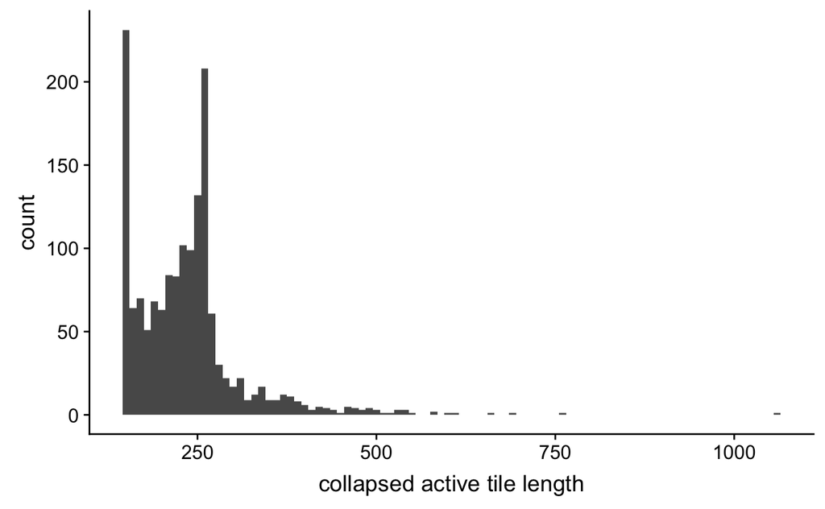

Let’s load in the previous endo TSS library

```r
endo <- read.table('../../processed_data/expression_pipeline/rLP5_Endo2_expression.txt',
                   header = T)

neg <- subset(endo, grepl("neg_control",endo$name))
neg_median <- median(neg$RNA_exp_ave)
neg_sd <- sd(neg$RNA_exp_ave)
threshold <- neg_median+3*(neg_sd)

endo_active <- filter(endo, RNA_exp_ave >= threshold)

num_overlaps <- numeric()
for(i in 1:nrow(collapsed)){
    overlaps <- 0
    x1 <- collapsed$tile_start[i]
    y1 <- collapsed$tile_end[i]
    for(j in 1:nrow(endo_active)){
        tss_overlap <- overlap(x1, y1, endo_active$start[j], endo_active$end[j])
        if(tss_overlap) { overlaps = overlaps + 1}
    }
    num_overlaps <- append(num_overlaps, overlaps)
}

collapsed$num_active_tss_overlap <- num_overlaps
table(collapsed$num_active_tss_overlap)
```

```r
length(which(collapsed$num_active_tss_overlap > 0)) / nrow(collapsed)
```

[output not shown]

How about the inactive ones?

```r
inactive <- arrange(inactive, peak_start, tile_start)

current <- inactive
curr_count <- nrow(current)
collapsed_count <- 0
while(collapsed_count != curr_count) {
    curr_count <- nrow(current)
    collapsed_inactive <- collapse_tiles(current)
    collapsed_count <- nrow(collapsed_inactive)
    current <- collapsed_inactive
    # print(c(curr_count, collapsed_count))
}
print(nrow(inactive))
print(nrow(collapsed_inactive))
```

[output not shown]

```r
num_overlaps <- numeric()
for(i in 1:nrow(collapsed_inactive)){
    overlaps <- 0
    x1 <- collapsed_inactive$tile_start[i]
    y1 <- collapsed_inactive$tile_end[i]
    for(j in 1:nrow(endo_active)){
        tss_overlap <- overlap(x1, y1, endo_active$start[j], endo_active$end[j])
        if(tss_overlap) { overlaps = overlaps + 1 }
    }
    num_overlaps <- append(num_overlaps, overlaps)
}

collapsed_inactive$num_active_tss_overlap <- num_overlaps
table(collapsed_inactive$num_active_tss_overlap)
```

```r
length(which(collapsed_inactive$num_active_tss_overlap > 0)) / nrow(collapsed_inactive)
```

[output not shown]